# Piloting Graph Learning in Children: CNL004 to CNL006

CNL006 hsa the updated version of the task, withtapping on the monsters to advance, tap as quickly as you can, the tap makes a sound, and string all assessments together rather than opening each separately. Also eliminated catch trials in the OMOT.

## CNL004

```r
suppressPackageStartupMessages(library(summarytools, quietly = TRUE))
suppressPackageStartupMessages(library(dplyr, quietly = TRUE))
logdir='/Users/utooley/Dropbox/projects/in_progress/network_learning/code/netlearn_kids_v1/logs/'
datadir='~/Dropbox/projects/in_progress/network_learning/code/netlearn_kids_v1/subjData/'
exposureData <- read.delim(paste0(logdir, "CNL004/CNL004_log_run1.csv"))
seqcmplData <- read.csv(paste0(datadir, "CNL004/seqcmpl/CNL004_log_seqcmpl.csv"))
omotData<- read.csv(paste0(datadir, "CNL004/OMOT/CNL004_log_omot.csv"))
#dyadicData<- read.csv(paste0(datadir, "CNL002/dyad_choice/CNL002_log_dyad_choice.csv"))
seqcmplData$correct <- factor(seqcmplData$correct, ordered=TRUE, labels=c("Incorrect", "Correct"))
exposureData$rt <- as.numeric(as.character(exposureData$rt))
```

### Exposure Data

```r
summary(exposureData$rt)
```

```
##    Min. 1st Qu.  Median    Mean 3rd Qu.    Max.
## 0.01742 0.02837 0.03957 0.35221 0.50646 4.33166
```

Wow, much faster!

**Does RT go down or up as the task goes on?**

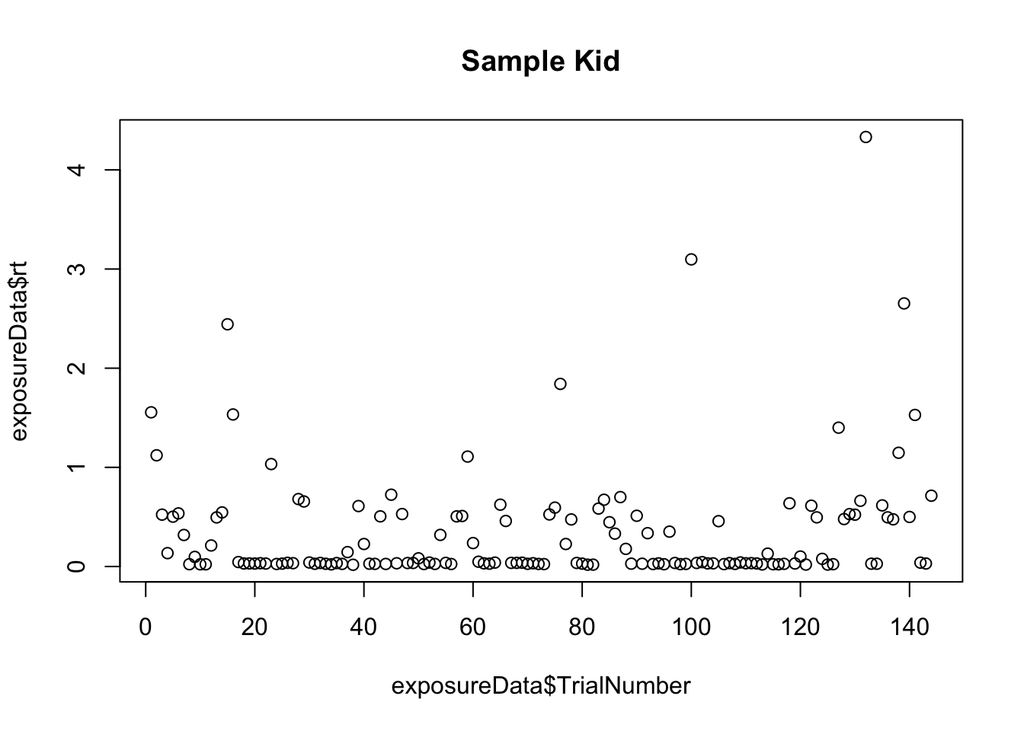

```r
plot(exposureData$TrialNumber, exposureData$rt, main="Sample Kid")
```

```r
cor.test(exposureData$TrialNumber, exposureData$rt)
```

```
##
##  Pearson's product-moment correlation
##
## data:  exposureData$TrialNumber and exposureData$rt
## t = 1.2987, df = 142, p-value = 0.1961
## alternative hypothesis: true correlation is not equal to 0
## 95 percent confidence interval:
##  -0.05622672  0.26718634
## sample estimates:
##       cor
## 0.1083457
```

**Is RT longer after transition nodes?**

```r
exposureData$transition_node <- ifelse((exposureData$node1==4 & exposureData$node2 ==5) |(exposureData$node1 ==5 & exposureData$node2 ==4), 1, 0)
exposureData$transition_node <- factor(exposureData$transition_node, labels=c("No", "Yes"))
exposureData %>%  group_by(transition_node) %>% summarise(avg_rt=mean(rt), med_rt=median(rt), std_dev=sd(rt), n_trials=n())
```

| transition_node | avg_rt | med_rt | std_dev | n_trials |
| --- | --- | --- | --- | --- |
| No | 0.3614060 | 0.04077160 | 0.616338015 | 140 |
| Yes | 0.0304951 | 0.02907855 | 0.007178786 | 4 |

No, not really.

**How long does it take with 150 nodes (of which 4 are practice trials)?**

```r
max(exposureData$onset)/60
```

```
## [1] 5.758433
```

## Sequence Completion Task

How many are correct? 75%.

```r
table(seqcmplData$correct)
```

```
##
## Incorrect   Correct
##         2         6
```

## Odd Man Out Task-Did not do

```r
summary(omotData$correct)
```

```
##    Min. 1st Qu.  Median    Mean 3rd Qu.    Max.
##  0.0000  0.0000  0.0000  0.2083  0.0000  1.0000
```

On average, 20% correct on OMOT.

Does average number correct differ by trial type?

```r
omotData %>% group_by(trial_type) %>% summarise(avg_correct=mean(correct))
```

| trial_type | avg_correct |
| --- | --- |
| catch | 0.33333333 |
| conservative | 0.27777778 |
| non_conservative | 0.05555556 |

**Does RT differ by trial type?**

```r
omotData %>% group_by(trial_type) %>% summarise(avg_rt=mean(rt), med_rt=median(rt), std_dev=sd(rt), n_trials=n())
```

| trial_type | avg_rt | med_rt | std_dev | n_trials |
| --- | --- | --- | --- | --- |
| catch | 4.132824 | 3.86078 | 2.19449 | 12 |
| conservative | 4.042444 | 3.21541 | 2.66518 | 18 |
| non_conservative | 3.173632 | 2.68823 | 1.79816 | 18 |

**Does RT differ by sequence-longer later in the sequence, or shorter?**

```r
cor.test(omotData$TrialNumber, omotData$rt)
```

```
##
##  Pearson's product-moment correlation
##
## data:  omotData$TrialNumber and omotData$rt
## t = -0.60132, df = 46, p-value = 0.5506
## alternative hypothesis: true correlation is not equal to 0
## 95 percent confidence interval:
##  -0.3633308  0.2008618
## sample estimates:
##         cor
## -0.08831309
```

### Conclusions

75% on sequence completion, but not successful at OMOT, on average 20%, which is below chance. No trial type was above chance. Took 5-6 minutes with 150 noges.

## CNL005

This participant was really tired by the end, though she did dyadic choice, she just tapped randomly, alternating between yes and no, so did not examine.

```r
exposureData <- read.delim(paste0(logdir, "CNL005/CNL005_log_run1.csv"))
seqcmplData <- read.csv(paste0(datadir, "CNL005/seqcmpl/CNL005_log_seqcmpl.csv"))
#omotData<- read.csv(paste0(datadir, "CNL005/OMOT/CNL005_log_omot.csv"))
#seqcmplData$correct <- factor(seqcmplData$correct, ordered=TRUE, levels=c(1,0), labels=c("Incorrect", "Correct"))
#omotData$correct <- factor(omotData$correct, ordered=TRUE, labels=c("Incorrect", "Correct")) #commented out because if make them factors then can't do proportion calculations on them.
```

## Check exposure data quality

```r
summary(exposureData$rt)
```

```
##    Min. 1st Qu.  Median    Mean 3rd Qu.    Max.
## 0.01759 0.58513 1.01669 0.96272 1.30237 3.04153
```

**Does RT go down or up as the task goes on?**

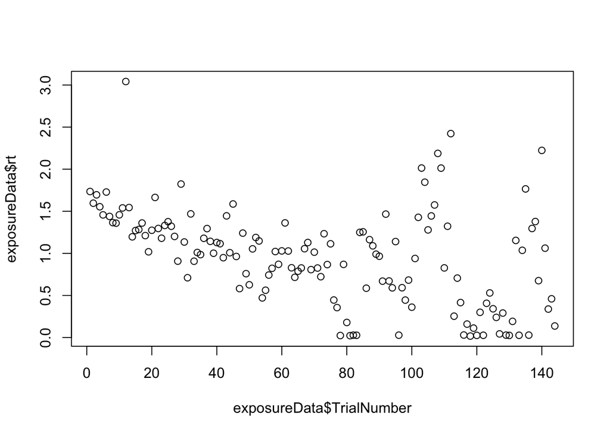

```r
plot(exposureData$TrialNumber, exposureData$rt)
```

```r
cor.test(exposureData$TrialNumber, exposureData$rt)
```

```
##
##  Pearson's product-moment correlation
##
## data:  exposureData$TrialNumber and exposureData$rt
## t = -6.0407, df = 142, p-value = 1.278e-08
## alternative hypothesis: true correlation is not equal to 0
## 95 percent confidence interval:
##  -0.5733215 -0.3116205
## sample estimates:
##        cor
## -0.4521488
```

It goes down (not surprisingly)!

**Is RT longer after transition nodes?**

```r
exposureData$transition_node <- ifelse((exposureData$node1==4 & exposureData$node2 ==5) |(exposureData$node1 ==5 & exposureData$node2 ==4), 1, 0)
exposureData$transition_node <- factor(exposureData$transition_node, labels=c("No", "Yes"))
exposureData %>%  group_by(transition_node) %>% summarise(avg_rt=mean(rt), med_rt=median(rt), std_dev=sd(rt), n_trials=n())
```

| transition_node | avg_rt | med_rt | std_dev | n_trials |
| --- | --- | --- | --- | --- |
| No | 0.9698468 | 1.016685 | 0.5671798 | 136 |
| Yes | 0.8414816 | 1.069635 | 0.5630684 | 8 |

Not really.

**How long does it take with 150 nodes?**

```r
max(exposureData$onset)/60
```

```
## [1] 7.279983
```

## Sequence Completion Task

```r
summary(seqcmplData$correct)
```

```
##    Min. 1st Qu.  Median    Mean 3rd Qu.    Max.
##   0.000   0.000   0.000   0.375   1.000   1.000
```

How many are correct? 37%

```r
table(seqcmplData$correct)
```

```
##
## 0 1
## 5 3
```

### Conclusions

Participant did not seem to want to try by the time we got to the assessments, it was still too long, perhaps? Sequence completion at 37% accuracy, below chance. Also did not incentivize right, maybe? Exposure was 7.3 min.

## CNL006

Here made the change for tapping on the monsters to advance, tap as quickly as you can, the tap makes a sound, and string all assessments together rather than opening each separately. Also removed catch trials from the OMOT.

```r
exposureData <- read.delim(paste0(logdir, "CNL006/CNL006_log_run1.csv"))
seqcmplData <- read.csv(paste0(datadir, "CNL006/seqcmpl/CNL006_log_seqcmpl.csv"))
omotData<- read.csv(paste0(datadir, "CNL006/OMOT/CNL006_log_omot.csv"))
#seqcmplData$correct <- factor(seqcmplData$correct, ordered=TRUE, levels=c(1,0), labels=c("Incorrect", "Correct"))
#omotData$correct <- factor(omotData$correct, ordered=TRUE, labels=c("Incorrect", "Correct")) #commented out because if make them factors then can't do proportion calculations on them.
```

## Exposure Data

```r
summary(exposureData$rt)
```

```
##    Min. 1st Qu.  Median    Mean 3rd Qu.    Max.
## 0.01077 1.21187 1.65122 1.78063 2.25953 4.70266
```

**Does RT go down or up as the task goes on?**

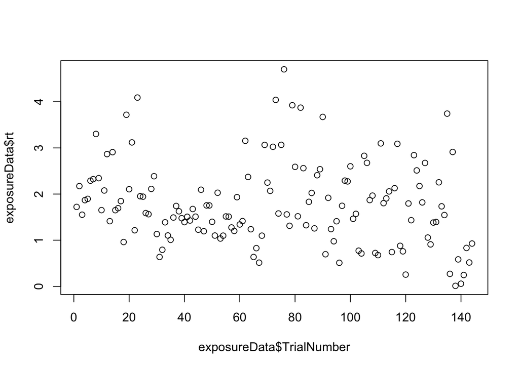

```r
plot(exposureData$TrialNumber, exposureData$rt)
```

```r
cor.test(exposureData$TrialNumber, exposureData$rt)
```

```
##
##  Pearson's product-moment correlation
##
## data:  exposureData$TrialNumber and exposureData$rt
## t = -1.9012, df = 142, p-value = 0.0593
## alternative hypothesis: true correlation is not equal to 0
## 95 percent confidence interval:
##  -0.313062454  0.006180379
## sample estimates:
##        cor
## -0.1575548
```

```r
exposureData$transition_node <- ifelse((exposureData$node1==4 & exposureData$node2 ==5) |(exposureData$node1 ==5 & exposureData$node2 ==4), 1, 0)
exposureData$transition_node <- factor(exposureData$transition_node, labels=c("No", "Yes"))
exposureData %>%  group_by(transition_node) %>% summarise(avg_rt=mean(rt), med_rt=median(rt), std_dev=sd(rt), n_trials=n())
```

| transition_node | avg_rt | med_rt | std_dev | n_trials |
| --- | --- | --- | --- | --- |
| No | 1.820657 | 1.721479 | 0.8931383 | 129 |
| Yes | 1.436436 | 1.413925 | 0.8339073 | 15 |

No, it’s not.

**How long does it take with 150 nodes?**

```r
max(exposureData$onset)/60
```

```
## [1] 8.672927
```

## Sequence Completion Task

Data quality

```r
summary(seqcmplData$correct)
```

```
##    Min. 1st Qu.  Median    Mean 3rd Qu.    Max.
##   0.000   0.000   1.000   0.625   1.000   1.000
```

How many are correct? 63%.

```r
table(seqcmplData$correct)
```

```
##
## 0 1
## 3 5
```

## Odd Man Out Task

```r
summary(omotData$correct)
```

```
##    Min. 1st Qu.  Median    Mean 3rd Qu.    Max.
##  0.0000  0.0000  0.0000  0.4667  1.0000  1.0000
```

47% correct on OMOT.

Does average number correct differ by trial type?

```r
omotData %>% group_by(trial_type) %>% summarise(avg_correct=mean(correct))
```

| trial_type | avg_correct |
| --- | --- |
| conservative | 0.6000000 |
| non_conservative | 0.3333333 |

Yes-above chance on conservative trials, but at chance on non-conservative trials.

**Does RT differ by trial type?**

```r
omotData %>% group_by(trial_type) %>% summarise(avg_rt=mean(rt), med_rt=median(rt), std_dev=sd(rt), n_trials=n())
```

| trial_type | avg_rt | med_rt | std_dev | n_trials |
| --- | --- | --- | --- | --- |
| conservative | 4.574482 | 4.384700 | 0.9103595 | 15 |
| non_conservative | 4.859252 | 4.665747 | 0.7784033 | 15 |

Higher in non-conservative trials, as expected.

**Does RT differ by sequence-longer later in the sequence, or shorter?**

```r
cor.test(omotData$TrialNumber, omotData$rt)
```

```
##
##  Pearson's product-moment correlation
##
## data:  omotData$TrialNumber and omotData$rt
## t = -1.0415, df = 28, p-value = 0.3065
## alternative hypothesis: true correlation is not equal to 0
## 95 percent confidence interval:
##  -0.5173927  0.1796468
## sample estimates:
##        cor
## -0.1931214
```

Not strongly so.